# Module 8 Lecture - Memory

Introductory Psychology

Quinton Quagliano, M.S., C.S.P

Department of Psychology

# 1 Overview and Introduction

Agenda

1 Overview and Introduction

2 How Memory Functions

3 Parts of the Brain Involved with Memory

4 Conclusion

## 1.1 Textbook Learning Objectives

- Discuss the three basic functions of memory
- Describe the three stages of memory storage
- Describe and distinguish between procedural and declarative memory and semantic and episodic memory
- Explain the brain functions involved in memory
- Recognize the roles of the hippocampus, amygdala, and cerebellum
- Compare and contrast the two types of amnesia
- Discuss the unreliability of eyewitness testimony
- Discuss encoding failure
- Discuss the various memory errors
- Compare and contrast the two types of interference

## 1.2 Instructor Learning Objectives

- Make sure you can connect memory back to the all important brain structures!
- Be able to apply the concepts of memory to anecdotal and narrative examples
- Be able to apply an understanding of memory vocabulary to your own life

## 1.3 Introduction

- **Important: Memory is one of the most crucial cognitive skills we have, and it is stressed constantly in education, because without it, we wouldn't be able to apply our knowledge after we graduate!**
- Memory is everywhere
  - When I ask you to identify a certain part of the brain $\rightarrow$ memory
  - When you remember the name of someone when they walk up to you $\rightarrow$ memory
  - When you think about your friends and family $\rightarrow$ memory
  - “Memory” is even present in small procedural things, like tying our shoes
- **Discuss: Tell me, what's your earliest memory?**

# 2 How Memory Functions

Agenda

1 Overview and Introduction

2 How Memory Functions

3 Parts of the Brain Involved with Memory

4 Conclusion

## 2.1 Introduction

- Our **memory** is a process of encoding information, storing it for some time, and retrieving it from storage
  - The following sections will detail more about each of these parts

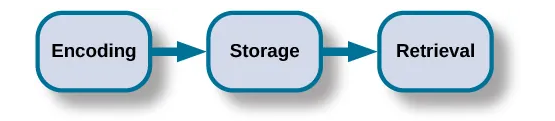

- **Question: Quick review: which one of these anatomical structures was said to deal a lot with memory during the biopsychology unit?**
- A) Occiptial lobe
- B) Pons
- C) Hippocampus
- D) Substantia Nigra

## 2.2 Encoding

- In order to remember something we must first sense it
- **Question: If I were to remember something I heard, what sensory receptor would have transduced that information into my brain?**
- A) Taste buds
- B) Photoreceptors
- C) Hair cells
- D) None of the above
- The process of turning that sensory information into memory is called **encoding**
  - There are two types of processing done as part of encoding: automatic and effortful
- As a general rule, the more meaningful something is, the easier it is to encode
- **Discuss: We've mention how something being 'meaningful' is important in previous units - where and how have we discussed this before?**

### Types of Processing in Encoding

- First, **automatic processing**, is the process by which we automatically encode memories without intending to
  - Tends to be less complex information
  - E.g., what color my car is, what my hair color is, what shirt I wore today and yesterday
- Second, **effortful processing** is that which we do with intention and effort, as the name would imply
  - Usually more complex information
  - E.g., memorizing a phone number or an address (in the old days), studying for a midterm exam
- **Discuss: I am running to the grocery store, but have no paper or phone to write down a list, so I memorize the vegetables I need and then run out of the house, find my car and leave. What processing did I do to memorize the vegetables and what processing did I do in being able to remember what my car looks like? Why?**

### Types of Encoding

- We can further break down types of encoding into:
  - Semantic
  - Visual
  - Acoustic
- First of these three, **semantic encoding**
  - Related to words and the meanings of those words
  - E.g., we remember the word ‘elaborate’ and it’s definition as, “explain something further”
  - We also tend to group together words in our memory that have similar or related meanings
- **Question: What is the most basic 'grouping' unit in our cognition, from the thinking and intelligence unit?**
- A) Schema
- B) Heuristic
- C) Algorithm
- D) Concept
- Next, **visual encoding** is related to our memory of images
  - E.g. I can remember the general visual and diagram of the brain, I visualize the idea of “car” when I see the word
- Finally **acoustic encoding** is related to our ability to encode sounds and auditory words
  - E.g., hearing a song a memorizing its melody, learning the 50 states and the alphabet song
- **Important: All of the above we related to words, but specifically how we interact with those words to memorize them!**
- Interestingly, of the three types above, semantic encoding tends to result in the best memory!
  - This is theorized to be related to what we call the **self-reference effect**, which is our tendency to more easily remember information relevant to ourself
- **Discuss: I am listening to the radio in my car on a long drive to a conference, and a popular song is played over and over again. I'm not paying much attention to the music - but as time goes on, I find myself starting to single along to the chorus each time I hear it. What type of processing is predominantly happening and what type of encoding is happening?**

## 2.3 Storage

- If encoding is how we take information in, then **storage** is how we keep it in our mind
  - But, there are multiple stages in a memory becoming long-term after being encoded, according to the **Atkinson and Shiffrin Model**:
    - Sensory memory
    - Short-term memory
    - Long-term memory
  - There are other models of memory formation, but we’ll focus on this one

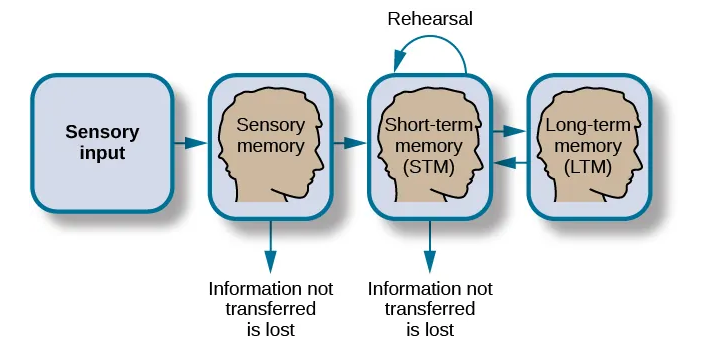

- **Important: We must first properly sense, process, and encode to have a memory in storage!**

### Sensory Memory

- The stage of **sensory memory** is when information is only very briefly held in our memory as sensory information
  - Most sensory memories evaporate near instantly!
  - Only information which we consider to be meaningful, even if unconsciously, will get retained
  - E.g., the sensory memory of the color of someone’s shirt passing on the sidewalk, I will likely not remember past just a moment, *unless* I thought it was a cool shirt
- **Discuss: Come up with you own example along the lines above, where a piece of sensory information is likely to get discarded unless you find it useful**

### Short-term Memory

- **Important: 'Short-term memory' and 'working memory' often get used similarly, but they are not quite the same.**
- The stage of **short-term memory** comes directly after sensory memory
  - Lasts around 15 to 30 seconds, but still longer than sensory memory
  - Importantly, short-term memory tends to connect information from sensory memory with something that already exists in long term memory.
- We can help move short-term memories to long-term by the process of **rehearsal**, which we might describe in two flavors:
  - Active rehearsal
  - Elaborate rehearsal
- The **active rehearsal**, moves information by simply repeating it many times
  - E.g., studying the brain by saying the names of the brain over and over again to get the sounds in our head
- **Question: Earlier we described several types of encoding - what type of encoding are we doing if we are mostly just focusing on the sounds of the words of the brain?**
- A) Auditory
- B) Semantic
- C) Visual
- D) None of the above
- Another type of rehearsal is **elaborate rehearsal**, which is when we connect new sensory information with that which we already have in long-term memory
  - E.g., I remember processes in our sense/perception module by connecting it closely with what I learned about the brain in the biopsychology module
  - I intentionally try to force a lot of elaborate rehearsal during lecture, to help you move new content to long-term from short term!
- **Discuss: Our brains tend to like make all sorts of connections, as it makes us efficient. Explain how the ideas of connections relates to role schemata and event schemata**

### Long-term Memory

- Our **long-term memory** is where are memories end up after being rehearsed enough or meaningful enough
- As we learned about a bit in our cognitive unit, our brain connects and groups things to organize
  - When it comes to memory, we tend to group words and ideas with **semantic networks**
- **Important: Basically, we were already talking about memory in the last unit, without calling it memory!**
- One of the important features of a semantic network is that we find that as one concept, word or idea is activated - related ideas also become somewhat activated
  - This creates a sort of route, through our brain to get to certain words and ideas
  - The more routes you can take (i.e., having more connections), the easier you can remember things!
- Within the broader class of Long-term memory, we have two further types: explicit and implicit, which also have their own divisions

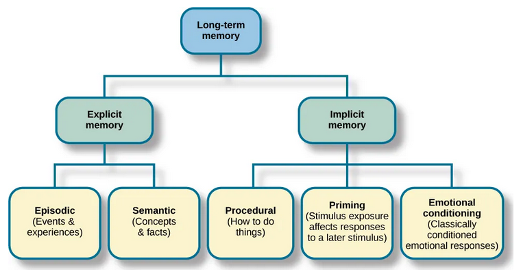

### Explicit Long-term Memory

- For **explicit memory**, these are those memories that we intentionally try to maintain, store, and remember in our long-term memory
  - E.g., when I ask you a review question in class, you *explicitly* try to remember it, or when you are trying to remember that really good restaurant you ate at one time
  - This splits into episodic memory and semantic memory
- Then **episodic memory** is all about a narrative experience
  - E.g., my memory of teaching last lecture section, my memory of testing patients at work today, your memory of talking with friends in your room earlier in the day
- **Discuss: Write your own example of an episode you remember from the last week?**
- Finally **semantic memory** deals with knowledge of facts and language
  - E.g., knowing an accurate synonym to the word ‘exhilarating’ is ‘exciting’, being able to correctly name the governor of Michigan, etc.

### Implicit Long-term Memory

- These **implicit memory** are those which we are not conscious or aware of
  - They cannot be recalled like explicit memories could be, and are more unseen
  - Further divided into:
    - Procedural
    - Priming
    - Emotional conditioning
    - We’ll just talk about the first two
- Our **procedural memory** are those which tell us how to do things, like the process involved
  - E.g., Riding a bike, brushing teeth, walking, etc.
  - Procedural memories often start intentional during the learning process, but become more automatic with time
- The idea of **priming** happens when we make a spontaneous connection and “primed” or biased to a specific semantic connection
  - E.g., unscramble the following word after this prompt:

## 2.4 Retrieval

- Once our memories are stored in long-term memory, we obviously hope to be able to pull them out to use! We call this process our **retrieval**.
- **Important: If we can't retrieve our memories, then they are inaccessible and temporarily useless**
- There are 3 types of retrieval:
  - Recall
  - Recognition
  - Relearning
- The process of **recall** is when we are able to pull memories from storage with no cues or hints
  - E.g., I can recall the names of grandparents without any hints, I can recall what my empirical papers are without hints
- Our **recognition** comes when we identify a familiar thing and recognize it
  - E.g., I could identify a dish in a foreign language on a menu as one that I’ve had before, but couldn’t remember the name until I saw the menu
- **Discuss: With our understanding of recall and recognition and described above, explain why a short answer test or multiple choice test is more difficult**
- Finally, **relearning** is when we just re-encode previously learned information, but now it comes to us faster

# 3 Parts of the Brain Involved with Memory

Agenda

1 Overview and Introduction

2 How Memory Functions

3 Parts of the Brain Involved with Memory

4 Conclusion

## 3.1 Introduction

- Unsurprisingly, the physical structures of the brain have been investigated as having special purposes related to our memories

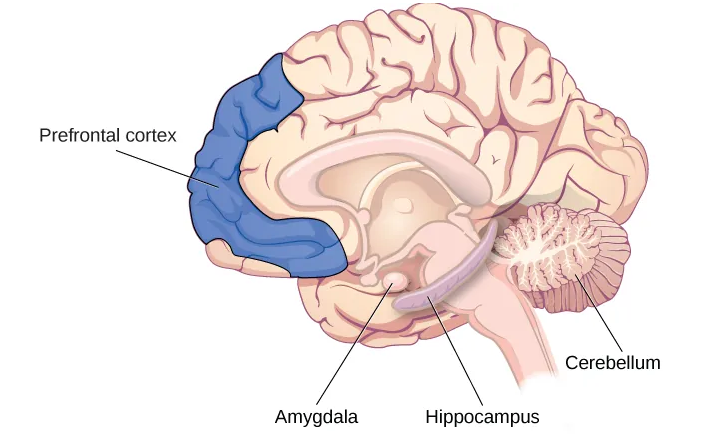

## 3.2 The Amygdala

- The amygdala is associated with emotional memories, and especially the encoding process of emotional memories
  - It also deals with **memory consolidation**
- **Important: It seems like encoding often works better when an event is emotionally arousing - likely because is is very personally relevant to us**
- **Question: What was our tendency to remember information relevant to ourself?**
- A) Self-feel effect
- B) Self-importance effect
- C) Self-centric effect
- D) Self-reference effect

## 3.3 The Hippocampus

- Empirical science would suggest that the hippocampus deals much with memory consolidation, as well as recognition memory
  - However, function of this area seems mostly related to explicit memories, and less to do with implicit types

## 3.4 The Cerebellum and Prefrontal Cortex

- The cerebellum seems fairly connected to procedural memory
- The prefrontal cortex seems like it deals much with the initial processing of information

# 4 Conclusion

Agenda

1 Overview and Introduction

2 How Memory Functions

3 Parts of the Brain Involved with Memory

4 Conclusion

## 4.1 Recap

- Memory is much more complex than just one simple construct: there are many different types!
- The way we come to store and retrieve information is very important, and there are many parts of encoding and storage process which modify whether sensory information will become long-term memories
- Memory is connected to several structures in the brain, which each have their own unique functions related to different types of memory
- We skipped talking about problems in memory and enhancing memory, for brevity, but consider reading through those sections if you want to learn more!

## 4.2 Lecture Check-in

- Make sure to complete any lecture check-in tasks associated with this lecture!

[figure not shown]

Module 8 Lecture - Memory || Introductory Psychology